# A computational account of niceness

Ryan Carlson, Michael Brau-Lopez, & Vlad Chituc

4/27/2018

### Models

Here we developed three computational models that make judgments of niceness:

- A *sacrifice model* that judges niceness based purely on ‘how much’ someone gives, independent of what’s given
- A *utilitarian model* that judges niceness based on how much someone gives of a thing that is valued by the recipient
- A *Theory of Mind model* that judges niceness based on beliefs (what an actor thinks the receiver values), desires (what the actor values), and actions (what action the actor takes)

These models can be found in the “models” folder in our GitHub repository: https://github.com/carlsonrw/niceness.

### Prosocial scenarios

Here we test these models ability to handle four common prosocial actions:

1. An obvious good deed: When an actor gives a gift that both the actor and recipient value
- Example: when your friend gifts you a really nice scarf that they also like
2. An empty good deed: When an actor gives a gift that they know the recipient does not really value
- Example: gifting a smelly sock as a joke at a Secret Santa
3. A ‘well-intended’ good deed : When an actor gives a gift that they believe the recipient values, but in fact does not
- Example: gifting a winter jacket to someone who is about to move to California
4. A ‘convenient’ good deed: When an actor gifts something that they do not value themselves, but believe the recipient values.
- Example: gifting a book when you happen to own two copies

Importantly, while these scenarios focus on gift giving, the themes of these four prosocial scenarios (empty, well-intended, and empty acts of kindness) extend across to a broad variety of prosocial domains such as donating, volunteering, offering emotional support, and cooperating in complex tasks.

### Predictions

Below, we visualize the predictions generated from each model of how nice an agent was deemed to be when performing the four prosocial acts above.

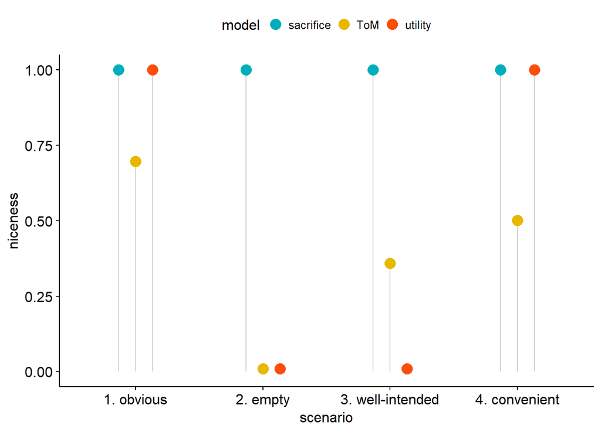

### Results

As we can see, all models can handle simple scenarios where a prosocial actor performs an obvious good deed. However, with increasingly complex social scenarios, the Theory of Mind model out-performs simplistic models, both correctly crediting agents’ who had good intentions, and penalizing those who gave out of convenience.

### Future directions

- Build a hybrid model that captures some weighted combination of all three models
- Build a model that captures outcomes (both personal benefits for actors and their actions to those benefits)
- Integrate knowledge of social norms for a given context into the sacrifice model

For more details, questions, or concerns contact ryan.carlson@yale.edu